# Exploratory analysis Eurofins data

## Data import & cleaning

For now, I focused only on the central Eurofins and Flemish data to get a better grip on the structure of the data. These datasets are not in a common format, all countries have different variables, different variable names, different units per variable, … Writing ad-hoc scripts per country will take some time.

```r
# methods used by Eurofins and national labs
methods_used <- read_excel(
  here("data", "Eurofins_comparison",
       "Results_and_Standards_EUROFINS_N_SIMS.xlsx"),
  sheet = "Standards_EUROFINS_and_N_SIMS"
)

source(here("source", "Eurofins", "import-clean-Eurofins.R"))
source(here("source", "Eurofins", "import-clean-Eurofins-Flanders.R"))
source(here("source", "Eurofins", "import-clean-Eurofins-Wallonia.R"))
```

Let’s look at 1 variable: `silt.` It’s a variable that is bounded between 0 and 1 (granulometric fraction).

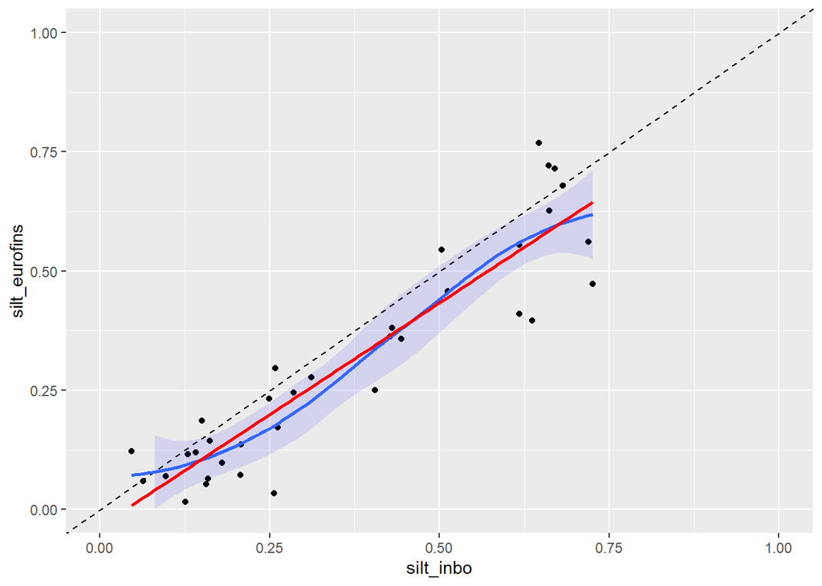

## Using Eurofins & NSIMS data to design the simulation experiment

In the complete simulation experiment we can simulate ad libitum the latent variables and add noise to them. However, we can design also another simulation study where we use the Eurofins/NSIMS data that mimics more closely the data we will see in real life. This should give better insights.

We could work as follows:

- Per soil variable, identify countries with different method than Eurofins.
- Identify which method is the reference method (see SML); let’s suppose that `silt_inbo` is the non-reference method ($X$) and `silt_eurofins` is the reference method ($Y$) and we want to validate a TF $X \rightarrow Y$.
- Let’s assume the dataset contains the true latent $X$ of a site and we will then simulate some measurement error on top of that. We specify the SD of the measurement error as a proportion of the SD of the latent $X$ (as in the other simulation study).

```r
# sd of latent x
sigma_x <- sd(data_silt$silt_inbo)

# sd of measurement error: specify as a proportion of the structural sigma_x
# choices: 0.05, 0.1, 0.2
sigma_mex <- sigma_x * 0.1
```

- To get a value for the latent $Y$, we fit a Bayesian model and take the fitted value as the latent parameter. For bounded variables like granulometric fractions, a natural choice is a Beta-model (priors need to be discussed):

$$\begin{eqnarray}
y_i \sim& Beta(\mu_i, \phi) \\
log\left(\frac{\mu_i}{1 - \mu_i}\right) =& \beta_0 + \beta_1x_i \\
\mathrm{log}(\phi) =& \alpha \\
\beta_0 \sim& N(0, 10) \\
\beta_1 \sim& N(0, 10) \\
\alpha \sim& \mathrm{Gamma}(.01,\ .01)
\end{eqnarray}$$

```r
pr <- c(
  prior("normal(0, 10)", class = "b"),
  prior("normal(0, 10)", class = "Intercept"),
  prior("gamma(0.01, 0.01)", class = "phi")
)
mod <- brm(
  silt_eurofins ~ silt_inbo,
  family = Beta("logit","log"),
  prior = pr,
  silent = 2, refresh = 0,
  data = data_silt
)
```

[output not shown]

[output not shown]

[output not shown]

[output not shown]

```r
summary(mod)
```

```
 Family: beta
  Links: mu = logit
Formula: silt_eurofins ~ silt_inbo
   Data: data_silt (Number of observations: 35)
  Draws: 4 chains, each with iter = 2000; warmup = 1000; thin = 1;
         total post-warmup draws = 4000

Regression Coefficients:
          Estimate Est.Error l-95% CI u-95% CI Rhat Bulk_ESS Tail_ESS
Intercept    -2.76      0.21    -3.17    -2.33 1.00     2370     2188
silt_inbo     4.80      0.44     3.93     5.65 1.00     2821     2368

Further Distributional Parameters:
    Estimate Est.Error l-95% CI u-95% CI Rhat Bulk_ESS Tail_ESS
phi    19.62      4.73    11.56    30.17 1.00     2715     2629

Draws were sampled using sampling(NUTS). For each parameter, Bulk_ESS
and Tail_ESS are effective sample size measures, and Rhat is the potential
scale reduction factor on split chains (at convergence, Rhat = 1).
```

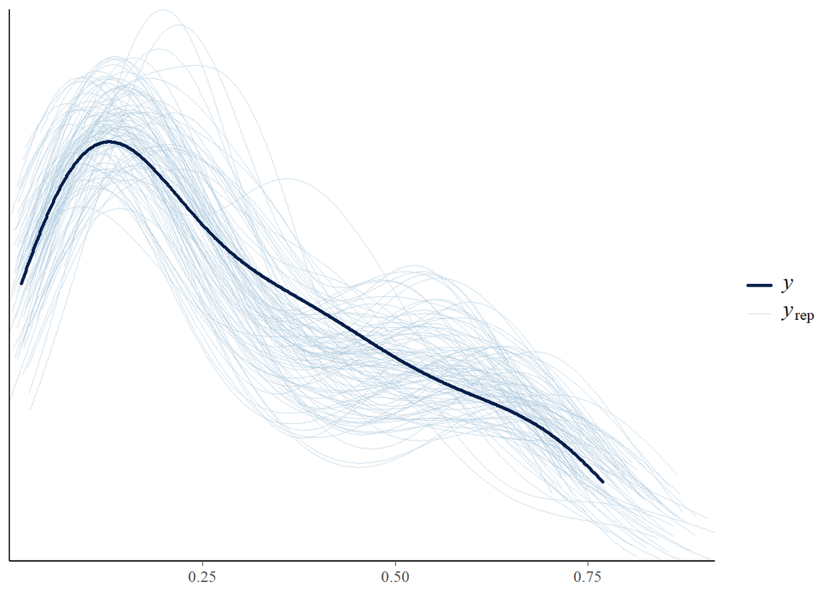

```r
pp_check(mod, trim = T, ndraws = 100)
```

We can construct the latent $Y$ then as follows:

- black = observed Eurofins-silt vs. “latent” INBO silt
- blue = “latent” Eurofins-silt vs. “latent” INBO silt

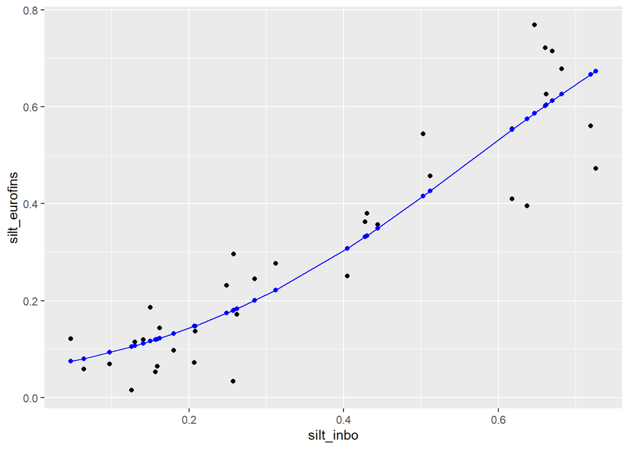

```r
data_silt <- data_silt %>%
  mutate(
    silt_eurofins_latent = apply(posterior_epred(mod), 2, mean),
  )
ggplot(data_silt) +
  geom_point(aes(silt_inbo, silt_eurofins), color = "black") +
  geom_point(aes(silt_inbo, silt_eurofins_latent), color = "blue") +
  geom_line(aes(silt_inbo, silt_eurofins_latent), color = "blue")
```

- We can now create two simulated datasets that mimic the original one. The first dataset has the same number of rows as the original dataset and will be used to train a model on data containing measurement error. The second independent dataset will be used to validate the predictions from the model (N = 1000).

```r
# training data
data_sims1 <- data.frame(
  x_obs  = data_silt$silt_inbo + rnorm(nrow(data_silt), 0, sigma_mex),
  y_obs  = posterior_predict(mod, ndraws = 1)[1,]
)
mod2 <- brm(
  y_obs ~ x_obs,
  family = Beta("logit","log"),
  prior = pr,
  silent = 2, refresh = 0,
  data = data_sims1
)
```

[output not shown]

[output not shown]

[output not shown]

[output not shown]

```r
summary(mod2)
```

```
 Family: beta
  Links: mu = logit
Formula: y_obs ~ x_obs
   Data: data_sims1 (Number of observations: 35)
  Draws: 4 chains, each with iter = 2000; warmup = 1000; thin = 1;
         total post-warmup draws = 4000

Regression Coefficients:
          Estimate Est.Error l-95% CI u-95% CI Rhat Bulk_ESS Tail_ESS
Intercept    -2.30      0.21    -2.71    -1.89 1.00     2677     2615
x_obs         4.52      0.46     3.60     5.41 1.00     2777     2532

Further Distributional Parameters:
    Estimate Est.Error l-95% CI u-95% CI Rhat Bulk_ESS Tail_ESS
phi    15.04      3.58     9.01    22.82 1.00     2322     2555

Draws were sampled using sampling(NUTS). For each parameter, Bulk_ESS
and Tail_ESS are effective sample size measures, and Rhat is the potential
scale reduction factor on split chains (at convergence, Rhat = 1).
```

```r
# testing data
N <- 1000
tmp <- data.frame(
  silt_inbo = sample(data_silt$silt_inbo, N, replace = T)
)
data_sims2 <- data.frame(
  x_true = tmp$silt_inbo,
  y_true = apply(posterior_epred(mod, newdata = tmp), 2, mean),
  x_obs  = tmp$silt_inbo + rnorm(N, 0, sigma_mex)
)
# predictions:
yhat  <- apply(posterior_epred(mod2, newdata = data_sims2), 2, mean)
yhatI <- predictive_interval(mod2, newdata = data_sims2, prob = .90)
data_sims2 <- data_sims2 %>%
  mutate(
    yhat    = yhat,
    yhat_ll = yhatI[,1],
    yhat_ul = yhatI[,2]
  )
# summarise predictions: mean absolute error & prediction interval coverage
data_sims2 %>%
  summarise(
    MAE  = mean(abs(yhat - y_true)),
    PICP = mean(between(y_true, yhat_ll, yhat_ul))
  )
```

```
         MAE PICP
1 0.05941265    1
```

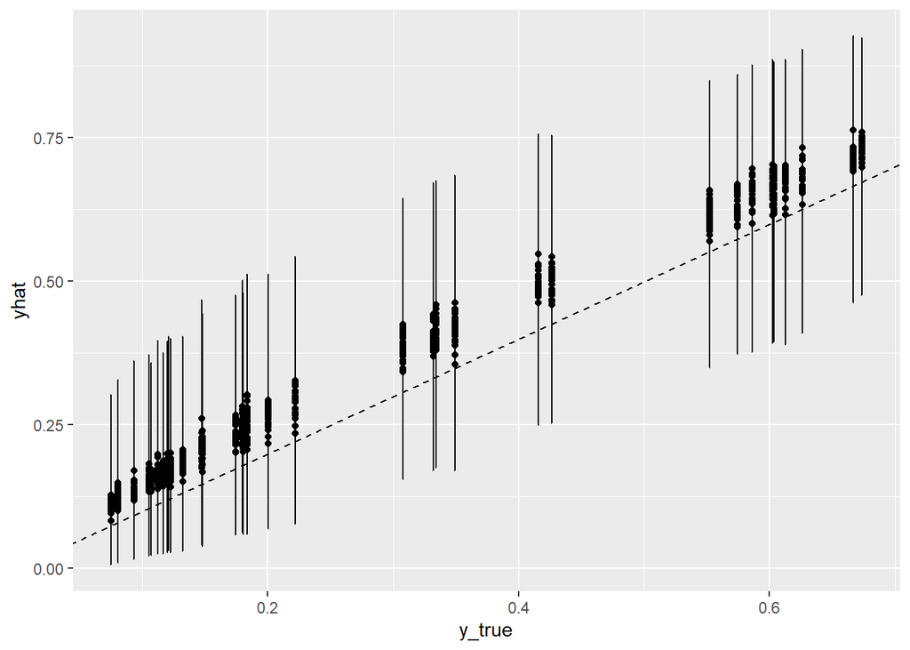

```r
ggplot(data_sims2, aes(y_true, yhat, ymin = yhat_ll, ymax = yhat_ul)) +
  geom_point() +
  geom_errorbar() +
  geom_abline(slope = 1, intercept = 0, lty = 2)
```

The MAE is reasonably low I think. However, the prediction intervals are not well calibrated, they are overly conservative. We asked for a 90% prediction interval, but the PICP was 100%. We’re seeing the same conservative behavior in the simulation experiment that is not based on real data. Of course in this example the Beta-regression was done on only 35 observations; reducing the uncertainty in the parameter estimates through more observation will probably reduce the prediction uncertainty.

## Dirichlet regression

The above regression treats `silt` as a single variable. However, the granulometric fractions sum to 1 and hence they should be modeled together so that the TF ($f$) preserves their sum:

$$\begin{aligned}
X_1 + X_2 + X_3 &= 1 \\
(Y_1, Y_2, Y_3) &= f(X_1, X_2, X_3) \\
Y_1 + Y_2 + Y_3 &= 1
\end{aligned}$$

A natural choice would be Dirichlet regression. Alternatives are log-ratio transformations (additive, centered, isometric). Let’s try Dirichlet regression first.

Question: when preparing the data, I noticed that the fractions don’t sum up to exactly 1. In the INBO dataset, the difference is maybe just a rounding issue, but in the Eurofins dataset there seems to be a systematic difference. For now I will just normalize everything to 1 to try the Dirichlet regression.

```r
data_granulometrics <- inner_join(
  data_eurofins_clean %>%
    select(identification, sand, silt, clay) %>%
    mutate(total_eurofins = sand + silt + clay) %>%
    rename(sand_eurofins = sand,
           silt_eurofins = silt,
           clay_eurofins = clay),
  data_inbo_fl_clean %>%
    select(identification, sand, silt, clay) %>%
    mutate(total_inbo = sand + silt + clay) %>%
    rename(sand_inbo = sand,
           silt_inbo = silt,
           clay_inbo = clay),
  by = "identification"
) %>%
  mutate(across(!identification, ~ as.numeric(.x)/100))

summary(data_granulometrics[,c("total_eurofins","total_inbo")])
```

```
 total_eurofins     total_inbo
 Min.   :0.8348   Min.   :0.9990
 1st Qu.:0.9461   1st Qu.:0.9995
 Median :0.9618   Median :1.0000
 Mean   :0.9507   Mean   :1.0000
 3rd Qu.:0.9694   3rd Qu.:1.0003
 Max.   :0.9751   Max.   :1.0010
```

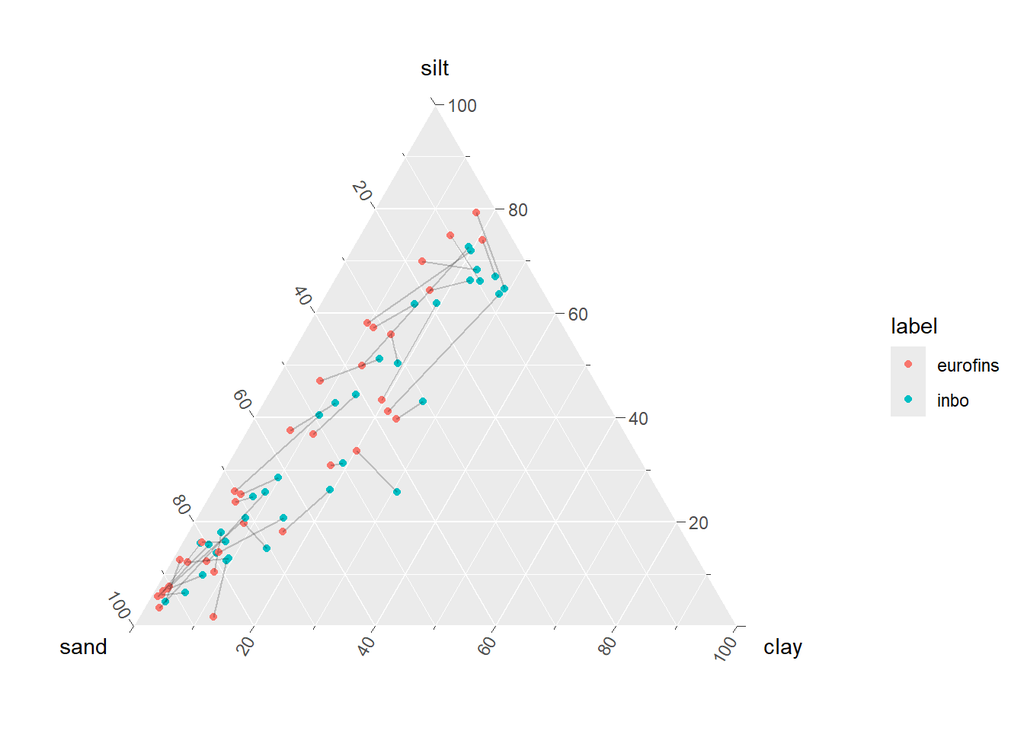

```r
# normalisation
data_granulometrics <- data_granulometrics %>%
  mutate(
    sand_eurofins = sand_eurofins / total_eurofins,
    silt_eurofins = silt_eurofins / total_eurofins,
    clay_eurofins = clay_eurofins / total_eurofins,
    total_eurofins = sand_eurofins + silt_eurofins + clay_eurofins,
    sand_inbo = sand_inbo / total_inbo,
    silt_inbo = silt_inbo / total_inbo,
    clay_inbo = clay_inbo / total_inbo,
    total_inbo = sand_inbo + clay_inbo + silt_inbo
  )

# simplex plot
library(ggtern) %>% suppressPackageStartupMessages()

spc <- data.frame(
  .name = c("sand_eurofins", "silt_eurofins", "clay_eurofins",
            "sand_inbo", "silt_inbo", "clay_inbo"),
  .value = rep(c("sand", "silt", "clay"), 2),
  label = rep(c("eurofins","inbo"), each = 3)
)
data_granulometrics %>%
  pivot_longer_spec(spc) %>%
  ggtern(aes(sand, silt, clay, group = identification, color = label)) +
  geom_point() + geom_line(color = "black", alpha = .2)
```

We fit the model using each of the three predictors as a linear term.

```r
data_granulometrics <- within(
  data_granulometrics,
  {Y <- cbind(sand_eurofins, silt_eurofins, clay_eurofins)}
)

dir_mod <- brm(
  Y ~ sand_inbo + silt_inbo + clay_inbo,
  family = dirichlet("logit","log", refcat = "silt_eurofins"),
  data = data_granulometrics
)
save(dir_mod, file = here("data/dir_mod.rda"))
```

Sampling takes a very long time and the model is not converging. We only have 35 observations for a model with 9 parameters, so that’s not very surprising. Next: try the log-ratio transformation models.

```r
load(here("data/dir_mod.rda"))
summary(dir_mod)
```

```
 Family: dirichlet
  Links: musandeurofins = logit; muclayeurofins = logit
Formula: Y ~ sand_inbo + silt_inbo + clay_inbo
   Data: data_granulometrics (Number of observations: 35)
  Draws: 4 chains, each with iter = 2000; warmup = 1000; thin = 1;
         total post-warmup draws = 4000

Regression Coefficients:
                         Estimate Est.Error l-95% CI u-95% CI Rhat Bulk_ESS
musandeurofins_Intercept  -510.62    816.90 -2396.50   572.19 1.80        6
muclayeurofins_Intercept   110.50   2527.76 -4746.00  3457.33 2.61        5
musandeurofins_sand_inbo   513.93    816.90  -568.90  2399.80 1.80        6
musandeurofins_silt_inbo   509.60    816.89  -573.36  2395.56 1.80        6
musandeurofins_clay_inbo   507.08    816.91  -577.43  2393.26 1.80        6
muclayeurofins_sand_inbo  -111.18   2527.72 -3458.00  4745.65 2.61        5
muclayeurofins_silt_inbo  -113.25   2527.75 -3460.11  4743.37 2.61        5
muclayeurofins_clay_inbo  -108.02   2527.78 -3455.76  4747.36 2.61        5
                         Tail_ESS
musandeurofins_Intercept       11
muclayeurofins_Intercept       12
musandeurofins_sand_inbo       11
musandeurofins_silt_inbo       11
musandeurofins_clay_inbo       11
muclayeurofins_sand_inbo       12
muclayeurofins_silt_inbo       12
muclayeurofins_clay_inbo       12

Further Distributional Parameters:
    Estimate Est.Error l-95% CI u-95% CI Rhat Bulk_ESS Tail_ESS
phi    30.10      5.06    21.28    41.22 1.07       66      116

Draws were sampled using sampling(NUTS). For each parameter, Bulk_ESS
and Tail_ESS are effective sample size measures, and Rhat is the potential
scale reduction factor on split chains (at convergence, Rhat = 1).
```